# **Final Submission**

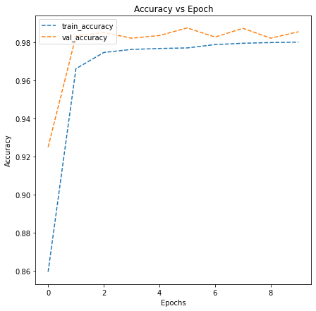

```python
# plotting the accuracies
plot_accuracy(historyGFX)
```

```python
# Evaluating the model on test data
accuracyGFX = modelGFX.evaluate(gfxtest, test_labels, verbose=1)
print('\n', 'Test_Accuracy:-', accuracyGFX[1])
```

```
 Test_Accuracy:- 0.9823076725006104
```

```
              precision    recall  f1-score   support

           0       0.98      0.99      0.98      1300
           1       0.99      0.98      0.98      1300

    accuracy                           0.98      2600
   macro avg       0.98      0.98      0.98      2600
weighted avg       0.98      0.98      0.98      2600
```

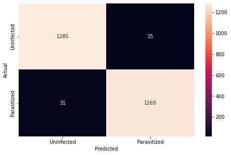

```python
pred = modelGFX.predict(gfxtest)
pred = np.argmax(pred,axis = 1)
y_true = np.argmax(test_labels ,axis = 1)
#Printing the classification report
print(classification_report(y_true, pred))

#Plotting the heatmap using confusion matrix
cm = confusion_matrix(y_true, pred)
plt.figure(figsize=(8,5))
sns.heatmap(cm, annot=True,  fmt='.0f', xticklabels=['Uninfected', 'Parasitized'], yticklabels=['Uninfected', 'Parasitized'])
plt.ylabel('Actual')
plt.xlabel('Predicted')
plt.show()
```

None of the image augmentation methods so far have increased model performance. Lets try using a slightly larger image size.

```python
# Loading the training and testing set folders

train_dirlg = '/content/cell_images/train'
test_dirlg = '/content/cell_images/test'

# Set image size

SIZELG = 100

# Create arrays to store images and labels

train_imageslg = []


test_imageslg = []
```

```python
#We will run the same code for "parasitized" as well as "uninfected" folders within the "train" folder
for folder_name in ['/parasitized/', '/uninfected/']:

    #Path of the folder
    images_pathlg = os.listdir(train_dirlg + folder_name)

    for i, image_name in enumerate(images_pathlg):
        try:
            #Opening each image using the path of that image
            image = Image.open(train_dirlg + folder_name + image_name)

            #Resizing each image to (100,100)
            image = image.resize((SIZELG, SIZELG))

            #Converting images to arrays and appending that array to the empty list defined above
            train_imageslg.append(np.array(image))


        except Exception:
            pass



#Converting lists to arrays

train_imageslg = np.array(train_imageslg)
```

```python
#We will run the same code for "parasitized" as well as "uninfected" folders within the "test" folder
for folder_name in ['/parasitized/', '/uninfected/']:

    #Path of the folder
    images_pathlg = os.listdir(test_dir + folder_name)

    for i, image_name in enumerate(images_pathlg):
        try:
            #Opening each image using the path of that image
            image = Image.open(test_dir + folder_name + image_name)

            #Resizing each image to (100,100)
            image = image.resize((SIZELG, SIZELG))

            #Converting images to arrays and appending that array to the empty list defined above
            test_imageslg.append(np.array(image))

        except Exception:
            pass



#Converting lists to arrays
test_imageslg = np.array(test_imageslg)
```

```python
print ("Train Image shape:", train_imageslg.shape)
print("Test image shape:", test_imageslg.shape)

print('-' * 30)

print ("Train labels shape:", train_labels.shape)
print("Test labels shape:", test_labels.shape)
```

```
Train Image shape: (24958, 100, 100, 3)
Test image shape: (2600, 100, 100, 3)
------------------------------
Train labels shape: (24958, 2)
Test labels shape: (2600, 2)
```

```python
# Checking the Mix Max value for larger images

print("Train images minimum value", train_imageslg.min())
print("Train images maximum value", train_imageslg.max())
print("Test images minimum value", test_imageslg.min())
print("Test images maximum value", test_imageslg.max())
```

```
Train images minimum value 0
Train images maximum value 255
Test images minimum value 0
Test images maximum value 255
```

```python
# Normalizing the RGB values so each pixel has a value between 0 and 1

train_imageslg = (train_imageslg/255).astype('float32')
test_imageslg = (test_imageslg/255).astype('float32')
```

```python
# Checking the Mix Max value for larger images

print("Train images minimum value", train_imageslg.min())
print("Train images maximum value", train_imageslg.max())
print("Test images minimum value", test_imageslg.min())
print("Test images maximum value", test_imageslg.max())
```

```
Train images minimum value 0.0
Train images maximum value 1.0
Test images minimum value 0.0
Test images maximum value 1.0
```

```python
# Clearing the backed and setting the random seed

reset_random_seeds
```

```
<function __main__.reset_random_seeds>
```

```python
#creating sequential model for larger image set
modellg=Sequential()
modellg.add(Conv2D(filters=32,kernel_size=2,padding="same",activation="relu",input_shape=(100,100,3)))
modellg.add(MaxPooling2D(pool_size=2))
modellg.add(Dropout(0.2))
modellg.add(Conv2D(filters=32,kernel_size=2,padding="same",activation="relu"))
modellg.add(MaxPooling2D(pool_size=2))
modellg.add(Dropout(0.2))
modellg.add(Conv2D(filters=32,kernel_size=2,padding="same",activation="relu"))
modellg.add(MaxPooling2D(pool_size=2))
modellg.add(Dropout(0.2))
modellg.add(Flatten())
modellg.add(Dense(512,activation="relu"))
modellg.add(Dropout(0.4))
modellg.add(Dense(2,activation="softmax"))
modellg.summary()
```

```
Model: "sequential_6"
_________________________________________________________________
 Layer (type)                Output Shape              Param #
=================================================================
 conv2d_18 (Conv2D)          (None, 100, 100, 32)      416

 max_pooling2d_18 (MaxPoolin  (None, 50, 50, 32)       0
 g2D)

 dropout_22 (Dropout)        (None, 50, 50, 32)        0

 conv2d_19 (Conv2D)          (None, 50, 50, 32)        4128

 max_pooling2d_19 (MaxPoolin  (None, 25, 25, 32)       0
 g2D)

 dropout_23 (Dropout)        (None, 25, 25, 32)        0

 conv2d_20 (Conv2D)          (None, 25, 25, 32)        4128

 max_pooling2d_20 (MaxPoolin  (None, 12, 12, 32)       0
 g2D)

 dropout_24 (Dropout)        (None, 12, 12, 32)        0

 flatten_7 (Flatten)         (None, 4608)              0

 dense_16 (Dense)            (None, 512)               2359808

 dropout_25 (Dropout)        (None, 512)               0

 dense_17 (Dense)            (None, 2)                 1026

=================================================================
Total params: 2,369,506
Trainable params: 2,369,506
Non-trainable params: 0
_________________________________________________________________
```

```python
# Compiling the model

modellg.compile(loss='binary_crossentropy', optimizer='adam', metrics=['accuracy'])
```

```python
# Using Callbacks to prevent model over fitting and improve processing times

callbacks = [EarlyStopping(monitor='val_loss', patience=2),
             ModelCheckpoint('.mdl_wts.hdf5', monitor='val_loss', save_best_only=True)]
```

```python
# Fitting and training our base model using larger images

historylg =modellg.fit(train_imageslg,train_labels,batch_size=32,callbacks=callbacks,validation_split=0.2,epochs=20,verbose=1)
```

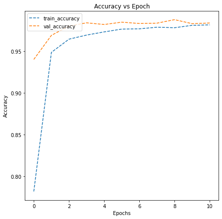

```python
# plotting the accuracies
plot_accuracy(historylg)
```

```python
# Evaluating the model on test data
accuracylg = modellg.evaluate(test_imageslg, test_labels, verbose=1)
print('\n', 'Test_Accuracy:-', accuracylg[1])
```

```
 Test_Accuracy:- 0.983846127986908
```

```
              precision    recall  f1-score   support

           0       0.98      0.98      0.98      1300
           1       0.98      0.98      0.98      1300

    accuracy                           0.98      2600
   macro avg       0.98      0.98      0.98      2600
weighted avg       0.98      0.98      0.98      2600
```

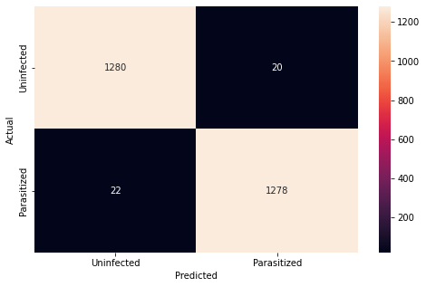

```python
pred = modellg.predict(test_imageslg)
pred = np.argmax(pred,axis = 1)
y_true = np.argmax(test_labels ,axis = 1)
#Printing the classification report
print(classification_report(y_true, pred))

#Plotting the heatmap using confusion matrix
cm = confusion_matrix(y_true, pred)
plt.figure(figsize=(8,5))
sns.heatmap(cm, annot=True,  fmt='.0f', xticklabels=['Uninfected', 'Parasitized'], yticklabels=['Uninfected', 'Parasitized'])
plt.ylabel('Actual')
plt.xlabel('Predicted')
plt.show()
```

# New Model Construction

Image augmentation inclusing HSV, Gaussian Blurring, and larger image sizes have not matierally improved model performance

Our base model continues to be among the best models tested, but the far more complex VGG model performed the worst. Perhaps a simpler model could improve model performance

```python
# Clearing the backed and setting the random seed

reset_random_seeds
```

```
<function __main__.reset_random_seeds>
```

```python
#creating sequential model
model5 = Sequential()
model5.add(Conv2D(filters = 32, kernel_size = (3, 3), padding = "same", input_shape = (64, 64, 3)))
model5.add(Activation('relu'))
model5.add(MaxPool2D(pool_size=(2,2)))
model5.add(Conv2D(64, (3,3)))
model5.add(Activation('relu'))
model5.add(MaxPool2D(pool_size=(2,2)))
model5.add(Conv2D(64, (3,3)))
model5.add(Activation('relu'))
model5.add(MaxPool2D(pool_size=(2,2)))
model5.add(Flatten())
model5.add(Dense(64, activation='relu'))
model5.add(Dropout(0.5))
model5.add(Dense(2, activation='softmax'))
model5.summary()
```

```
Model: "sequential_15"
_________________________________________________________________
 Layer (type)                Output Shape              Param #
=================================================================
 conv2d_45 (Conv2D)          (None, 64, 64, 32)        896

 activation_27 (Activation)  (None, 64, 64, 32)        0

 max_pooling2d_45 (MaxPoolin  (None, 32, 32, 32)       0
 g2D)

 conv2d_46 (Conv2D)          (None, 30, 30, 64)        18496

 activation_28 (Activation)  (None, 30, 30, 64)        0

 max_pooling2d_46 (MaxPoolin  (None, 15, 15, 64)       0
 g2D)

 conv2d_47 (Conv2D)          (None, 13, 13, 64)        36928

 activation_29 (Activation)  (None, 13, 13, 64)        0

 max_pooling2d_47 (MaxPoolin  (None, 6, 6, 64)         0
 g2D)

 flatten_16 (Flatten)        (None, 2304)              0

 dense_34 (Dense)            (None, 64)                147520

 dropout_34 (Dropout)        (None, 64)                0

 dense_35 (Dense)            (None, 2)                 130

=================================================================
Total params: 203,970
Trainable params: 203,970
Non-trainable params: 0
_________________________________________________________________
```

```python
# Compiling the model using different loss optimization

model5.compile(loss='categorical_crossentropy', optimizer='adam', metrics=['accuracy'])
```

```python
# Adding Callbacks to the model

callbacks = [EarlyStopping(monitor='val_loss', patience=2),
             ModelCheckpoint('.mdl_wts.hdf5', monitor='val_loss', save_best_only=True)]
```

```python
#Training the model

history5=model5.fit(train_images,train_labels,batch_size=32, callbacks = callbacks, validation_split=0.2,epochs=30,verbose=1)
```

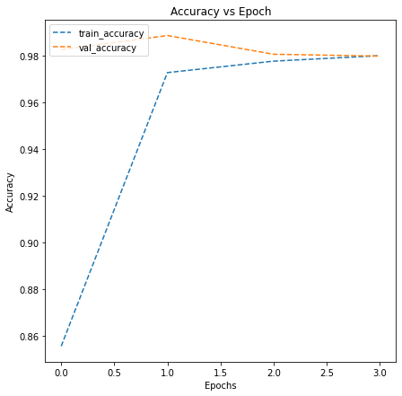

```python
# plotting the accuracies
plot_accuracy(history5)
```

```python
# Evaluating the model on test data
accuracy5 = model5.evaluate(test_images, test_labels, verbose=1)
print('\n', 'Test_Accuracy:-', accuracy5[1])# Evaluating the model on test data
accuracy5 = model5.evaluate(test_images, test_labels, verbose=1)
print('\n', 'Test_Accuracy:-', accuracy5[1])
```

```
 Test_Accuracy:- 0.9876922965049744

 Test_Accuracy:- 0.9876922965049744
```

```
              precision    recall  f1-score   support

           0       0.99      0.98      0.99      1300
           1       0.98      0.99      0.99      1300

    accuracy                           0.99      2600
   macro avg       0.99      0.99      0.99      2600
weighted avg       0.99      0.99      0.99      2600
```

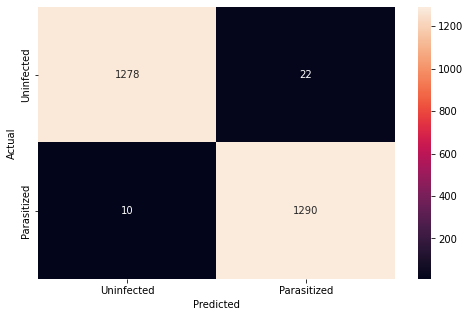

```python
# Plot the confusion matrix and generate a classification report for the model

pred = model5.predict(test_images)
pred = np.argmax(pred,axis = 1)
y_true = np.argmax(test_labels ,axis = 1)
#Printing the classification report
print(classification_report(y_true, pred))

#Plotting the heatmap using confusion matrix
cm = confusion_matrix(y_true, pred)
plt.figure(figsize=(8,5))
sns.heatmap(cm, annot=True,  fmt='.0f', xticklabels=['Uninfected', 'Parasitized'], yticklabels=['Uninfected', 'Parasitized'])
plt.ylabel('Actual')
plt.xlabel('Predicted')
plt.show()
```

```python
# Clearing the backed and setting the random seed

reset_random_seeds
```

```
<function __main__.reset_random_seeds>
```

```python
# New Model with reduced batch size
#creating sequential model
model6 = Sequential()
model6.add(Conv2D(filters = 32, kernel_size = (3, 3), padding = "same", input_shape = (64, 64, 3)))
model6.add(Activation('relu'))
model6.add(MaxPool2D(pool_size=(2,2)))
model6.add(Conv2D(64, (3,3)))
model6.add(Activation('relu'))
model6.add(MaxPool2D(pool_size=(2,2)))
model6.add(Conv2D(64, (3,3)))
model6.add(Activation('relu'))
model6.add(MaxPool2D(pool_size=(2,2)))
model6.add(Flatten())
model6.add(Dense(64, activation='relu'))
model6.add(Dropout(0.5))
model6.add(Dense(2, activation='softmax'))
model6.summary()
```

```
Model: "sequential_16"
_________________________________________________________________
 Layer (type)                Output Shape              Param #
=================================================================
 conv2d_48 (Conv2D)          (None, 64, 64, 32)        896

 activation_30 (Activation)  (None, 64, 64, 32)        0

 max_pooling2d_48 (MaxPoolin  (None, 32, 32, 32)       0
 g2D)

 conv2d_49 (Conv2D)          (None, 30, 30, 64)        18496

 activation_31 (Activation)  (None, 30, 30, 64)        0

 max_pooling2d_49 (MaxPoolin  (None, 15, 15, 64)       0
 g2D)

 conv2d_50 (Conv2D)          (None, 13, 13, 64)        36928

 activation_32 (Activation)  (None, 13, 13, 64)        0

 max_pooling2d_50 (MaxPoolin  (None, 6, 6, 64)         0
 g2D)

 flatten_17 (Flatten)        (None, 2304)              0

 dense_36 (Dense)            (None, 64)                147520

 dropout_35 (Dropout)        (None, 64)                0

 dense_37 (Dense)            (None, 2)                 130

=================================================================
Total params: 203,970
Trainable params: 203,970
Non-trainable params: 0
_________________________________________________________________
```

```python
# Compiling the model

model6.compile(loss='categorical_crossentropy', optimizer='adam', metrics=['accuracy'])
```

```python
#Training the model

history6=model6.fit(train_images,train_labels,batch_size=16, callbacks = callbacks, validation_split=0.2,epochs=30,verbose=1)
```

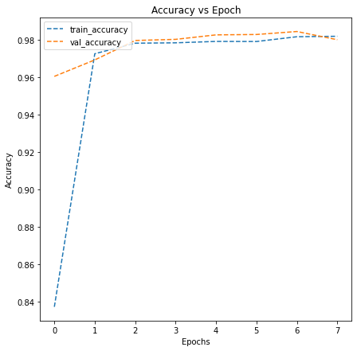

```python
# plotting the accuracies
plot_accuracy(history6)
```

```python
# Evaluating the model on test data
accuracy6 = model6.evaluate(test_images, test_labels, verbose=1)
print('\n', 'Test_Accuracy:-', accuracy6[1])
```

```
 Test_Accuracy:- 0.9876922965049744
```

```
              precision    recall  f1-score   support

           0       0.99      0.99      0.99      1300
           1       0.99      0.99      0.99      1300

    accuracy                           0.99      2600
   macro avg       0.99      0.99      0.99      2600
weighted avg       0.99      0.99      0.99      2600
```

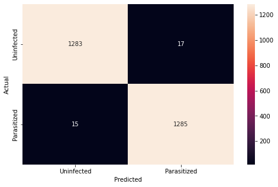

```python
# Plot the confusion matrix and generate a classification report for the model

pred = model6.predict(test_images)
pred = np.argmax(pred,axis = 1)
y_true = np.argmax(test_labels ,axis = 1)
#Printing the classification report
print(classification_report(y_true, pred))

#Plotting the heatmap using confusion matrix
cm = confusion_matrix(y_true, pred)
plt.figure(figsize=(8,5))
sns.heatmap(cm, annot=True,  fmt='.0f', xticklabels=['Uninfected', 'Parasitized'], yticklabels=['Uninfected', 'Parasitized'])
plt.ylabel('Actual')
plt.xlabel('Predicted')
plt.show()
```